# NHANES Diabetes Patient Data

## Investigation Overview

> The National Health and Nutrition Examination Survey (NHANES) is a program of studies designed to assess the health and nutritional status of adults and children in the United States.

> The goal of this analysis is to examine patient Diabetes and associated patient related comorbidities.

## Dataset Overview

> The NHANES interview includes demographic, socioeconomic, dietary, and health-related questions. The examination component consists of medical, dental, and physiological measurements, as well as laboratory tests administered by highly trained medical personnel.

```python
# import all packages and set plots to be embedded inline
import numpy as np
import pandas as pd
import matplotlib.pyplot as plt
import seaborn as sb

%matplotlib inline

# suppress warnings from final output
import warnings
warnings.simplefilter("ignore");
```

```python
# load in the dataset into a pandas dataframe
df_final = pd.read_csv('df_final.csv')
df_final.loc[df_final['Age_Years'] < 18 , 'Adult'] = 0
df_final.loc[(df_final['Age_Years'] >= 18), 'Adult'] = 1;
```

> Note that the above cells have been set as "Skip"-type slides. That means that when the notebook is rendered as http slides, those cells won't show up.

## Distribution of Patient Age

> The distribution of patients by age leans heavily towards children with the adults capped at 80.

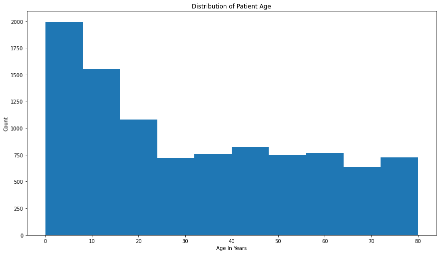

```python
# plot the distribution of members' Age

plt.figure(figsize=[14.70, 8.27])
plt.hist(df_final['Age_Years'].dropna(), bins=10)
plt.xlabel('Age In Years')
plt.ylabel('Count')
plt.title('Distribution of Patient Age');
```

## Distribution of BMI

> BMI is a combination of Weight To Height. BMI Index 25 to 30 is considered over weight. 30 and above is considered to be obese.  
> The patient data set indicates that there is a positive correlation between weight/BMI and rising A1C.

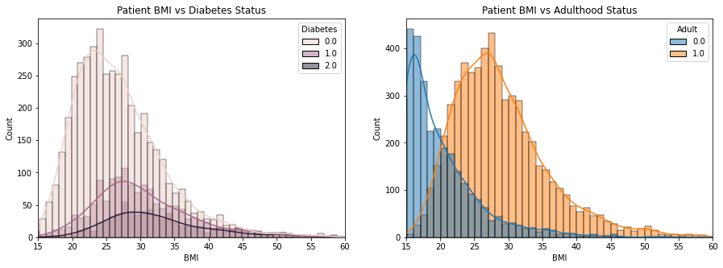

```python
f = plt.figure(figsize=(15,5))
plt.subplot(1,2,1)

# plot member's BMI vs Diabetes
sb.histplot(data=df_final, x = 'BMI', hue = 'Diabetes', kde=True)
plt.xlabel('BMI')
plt.ylabel('Count')
plt.xlim(left=15,right=60)
plt.title('Patient BMI vs Diabetes Status');

plt.subplot(1,2,2)
# plot member's BMI vs Adult Status
sb.histplot(data=df_final, x = 'BMI', hue = 'Adult', kde=True)
plt.xlabel('BMI')
plt.ylabel('Count')
plt.xlim(left=15,right=60)
plt.title('Patient BMI vs Adulthood Status');

plt.show();
```

## Distribution of GlycoHemoglobin (A1C)

> Diabetes is measured by patient average blood sugar levels called GLycoHemoglobin. Patients without diabetes average 5.6 and below. Between 5.7 and 6.3 are considered to be prediabetes. 6.4 and above are considered to have diabetes.

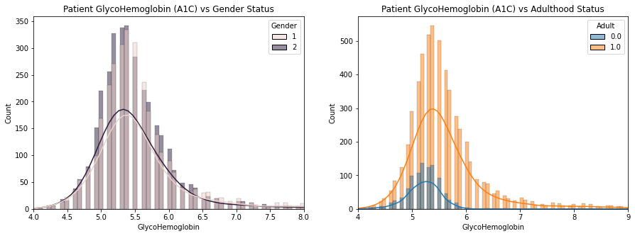

```python
f = plt.figure(figsize=(15,5))
plt.subplot(1,2,1)

# plot member's BMI vs Gender
sb.histplot(data=df_final, x = 'GlycoHemoglobin', hue = 'Gender', kde=True)
plt.xlabel('GlycoHemoglobin')
plt.ylabel('Count')
plt.xlim(left=4,right=8)
plt.title('Patient GlycoHemoglobin (A1C) vs Gender Status');

plt.subplot(1,2,2)
# plot member's BMI vs Adult Status
sb.histplot(data=df_final, x = 'GlycoHemoglobin', hue = 'Adult', kde=True)
plt.xlabel('GlycoHemoglobin')
plt.ylabel('Count')
plt.xlim(left=4,right=9)
plt.title('Patient GlycoHemoglobin (A1C) vs Adulthood Status');

plt.show();
```

## A1C and Diastolic/Systolic Blood Pressure

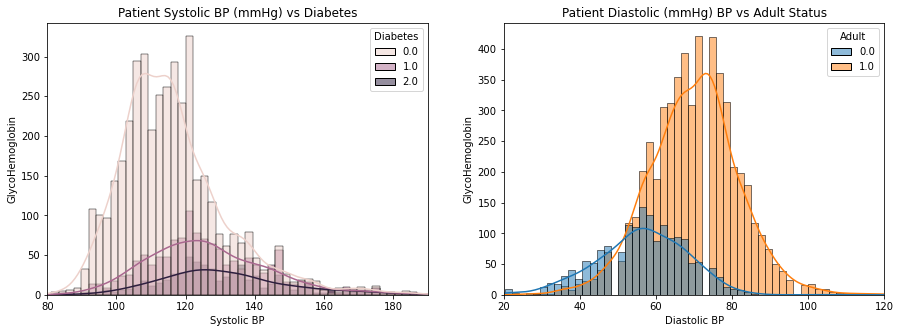

```python
f = plt.figure(figsize=(15,5))
plt.subplot(1,2,1)

# plot member's Systolic BP vs Diabetes
sb.histplot(data=df_final, x='Systolic_BP', hue='Diabetes', kde=True)
plt.xlabel('Systolic BP')
plt.ylabel('GlycoHemoglobin')
plt.xlim(left=80,right=190)
plt.title('Patient Systolic BP (mmHg) vs Diabetes');


plt.subplot(1,2,2)
# plot member's Diastolic BP vs Diabetes
sb.histplot(data=df_final, x='Diastolic_BP', hue='Adult', kde=True)
plt.xlabel('Diastolic BP')
plt.ylabel('GlycoHemoglobin')
plt.xlim(left=20,right=120)
plt.title('Patient Diastolic (mmHg) BP vs Adult Status');

plt.show();
```

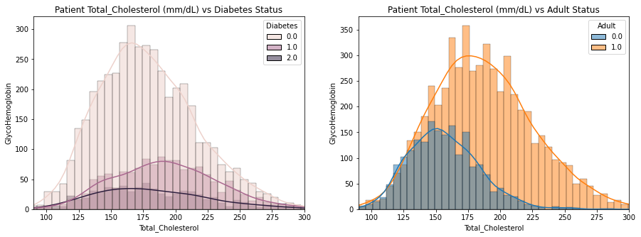

```python
f = plt.figure(figsize=(15,5))
plt.subplot(1,2,1)

# plot member's Total_Cholesterol vs Diabetes
sb.histplot(data=df_final, x='Total_Cholesterol', hue='Diabetes', kde=True)
plt.xlabel('Total_Cholesterol')
plt.ylabel('GlycoHemoglobin')
plt.xlim(left=90,right=300)
plt.title('Patient Total_Cholesterol (mm/dL) vs Diabetes Status');

plt.subplot(1,2,2)
# plot member's Total_Cholesterol vs Diabetes
sb.histplot(data=df_final, x='Total_Cholesterol', hue='Adult', kde=True)
plt.xlabel('Total_Cholesterol')
plt.ylabel('GlycoHemoglobin')
plt.xlim(left=90,right=300)
plt.title('Patient Total_Cholesterol (mm/dL) vs Adult Status');

plt.show();
```

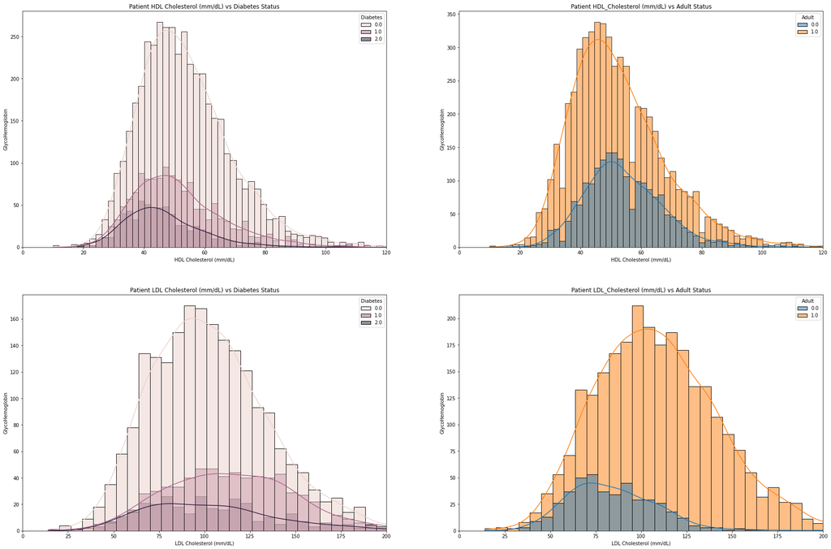

```python
f = plt.figure(figsize=(30,20))
plt.subplot(2,2,1)
# plot member's HDL_Cholesterol vs Diabetes
sb.histplot(data=df_final, x='HDL', hue='Diabetes', kde=True)
plt.xlabel('HDL Cholesterol (mm/dL)')
plt.ylabel('GlycoHemoglobin')
plt.xlim(left=0,right=120)
plt.title('Patient HDL Cholesterol (mm/dL) vs Diabetes Status');

plt.subplot(2,2,2)
# plot member's HDL_Cholesterol vs Diabetes
sb.histplot(data=df_final, x='HDL', hue='Adult', kde=True)
plt.xlabel('HDL Cholesterol (mm/dL)')
plt.ylabel('GlycoHemoglobin')
plt.xlim(left=0,right=120)
plt.title('Patient HDL_Cholesterol (mm/dL) vs Adult Status');

plt.subplot(2,2,3)
# plot member's LDL_Cholesterol vs Diabetes
sb.histplot(data=df_final, x='LDL', hue='Diabetes', kde=True)
plt.xlabel('LDL Cholesterol (mm/dL)')
plt.ylabel('GlycoHemoglobin')
plt.xlim(left=0,right=200)
plt.title('Patient LDL Cholesterol (mm/dL) vs Diabetes Status');

plt.subplot(2,2,4)
# plot member's LDL_Cholesterol vs Diabetes
sb.histplot(data=df_final, x='LDL', hue='Adult', kde=True)
plt.xlabel('LDL Cholesterol (mm/dL)')
plt.ylabel('GlycoHemoglobin')
plt.xlim(left=0,right=200)
plt.title('Patient LDL_Cholesterol (mm/dL) vs Adult Status');

plt.show();
```

## A1C and Triglycerides

> High triglycerides doesn't lead to diabetes, but their levels indicate that the system for turning food into energy isn't working properly. Normally, your body makes insulin, which “escorts” glucose -- the type of sugar in your blood --inside your cells. There, your body turns glucose into energy. The data shows a positive correlation between diabetes and triglycerides.

> Charts indicate a positive relationship between Triglycerides and Diabetes.

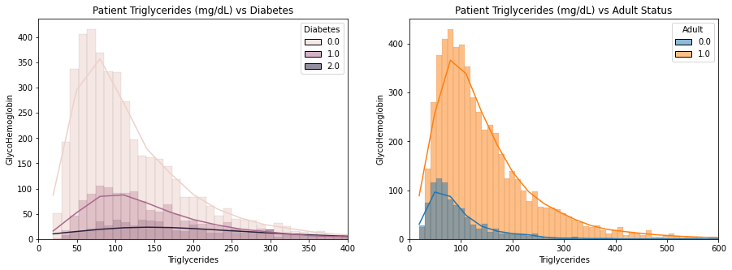

```python
f = plt.figure(figsize=(15,5))

plt.subplot(1,2,1)
# plot member's Triglycerides vs Diabetes
sb.histplot(data=df_final, x='Triglycerides', hue='Diabetes', kde=True)
plt.xlabel('Triglycerides')
plt.ylabel('GlycoHemoglobin')
plt.xlim(left=0,right=400)
plt.title('Patient Triglycerides (mg/dL) vs Diabetes');

plt.subplot(1,2,2)
# plot member's Triglycerides vs Adult Status
sb.histplot(data=df_final, x='Triglycerides', hue='Adult', kde=True)
plt.xlabel('Triglycerides')
plt.ylabel('GlycoHemoglobin')
plt.xlim(left=0,right=600)
plt.title('Patient Triglycerides (mg/dL) vs Adult Status');

plt.show();
```

## Data Set Parameters Correlation

> The correlation map shows mathematically how the parameters relate to each other. Age, Weight/BMI, Triglycerides, and Systolic Blood Pressure have a positive correlation with Diabetes. There are insignificant correlations between Cholesterol and Diastolic Blood Pressure and Diabetes.

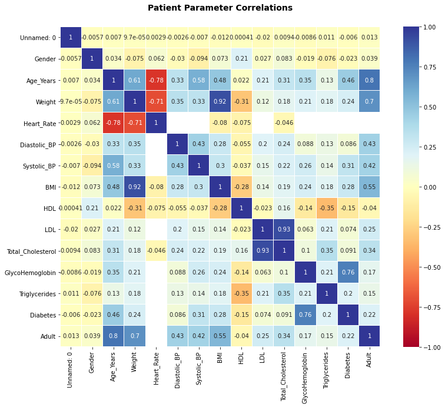

```python
# plot colormap of data set parameters and their correlations
plt.figure(figsize=(14, 10))
sb.heatmap(df_final.astype(float).drop(axis=1, labels='ID').corr(), linewidths=0.1, vmax=1.0, vmin = -1.0, square=True, cmap="RdYlBu", annot=True)
plt.title('Patient Parameter Correlations'.title(), y=1.04,
            fontsize = 14, weight = "bold");
```

## A1C and Triglycerides

High triglycerides doesn't lead to diabetes, but their levels indicate that the system for turning food into energy isn't working properly. Normally, your body makes insulin, which “escorts” glucose -- the type of sugar in your blood --inside your cells. There, your body turns glucose into energy. The data shows a positive correlation between diabetes and triglycerides.

Charts indicate a positive relationship between Triglycerides and Diabetes. Chart shows separation between Adulthood status and Gender.

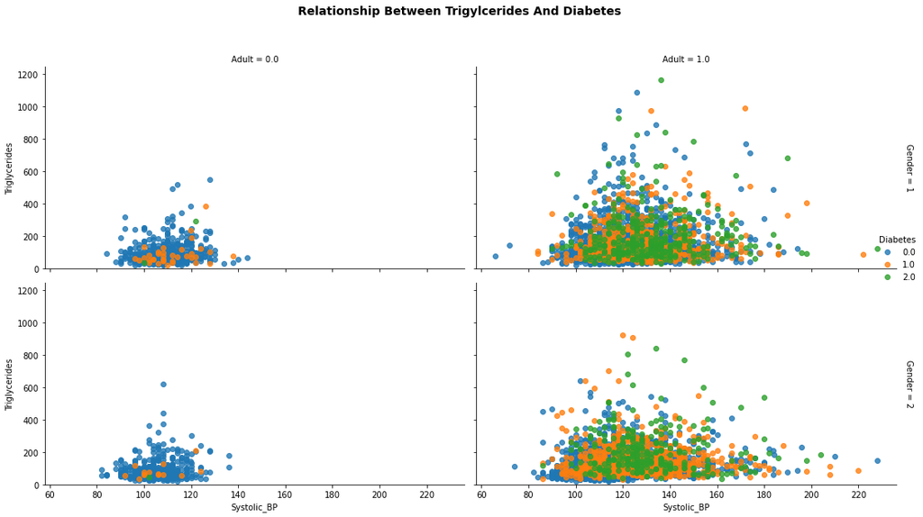

```python
# A1C and Triglycerides
g = sb.FacetGrid(df_final, hue="Diabetes", row="Gender", col="Adult",
                 margin_titles=True, ylim=(0,1250),
                height=8.27/2, aspect = (14.70/2)/(8.27/2), # set plot dimensions
                legend_out=True)
g.map(sb.regplot, "Systolic_BP", "Triglycerides", fit_reg=False, x_jitter=.01)
# add main title
plt.suptitle("Relationship between Trigylcerides and Diabetes".title(), y=1.04,
            fontsize = 14, weight = "bold")

# add and position legend
g.add_legend()
# optimize distance between subplots
plt.tight_layout();
```

## Credits:

> "Type 2." diabetes.org. American Diabetes Association. n.d. Web. (date accessed: 2/18/2021). 2018 AHA/ACC/AACVPR/AAPA/ABC/ACPM/ADA/AGS/APhA/ASPC/NLA/PCNA Guideline on the Management of Blood

> Cholesterol: A Report of the American College of Cardiology/American Heart Association Task Force on Clinical Practice Guidelines J Am Coll Cardiol. 2019 Jun, 73 (24) e285–e350

> Hypertriglyceridemia Management According to the 2018 AHA/ACC Guideline (see above)

> National Health and Nutrition Examination Survey NHANES datasets from 2013-2014 Centers for Disease Control and Prevention • updated 4 years ago (Version 1) from Kaggle.com

> Udacity and project reviewers for tips and suggestions.